# PulmonDB - COVID19.

##### **PCA with batch correction**

**v1 ggbiplot**

```r
## labels
experiments <- rep(
  c("Mk", "Mk+ACE2", "SC2", "SC2+ACE2", "SC2+ACE2+pt","Lung -","Lung COVID"),
  c(13, 6, 6, 6, 3, 2, 2))
experiments <- c(experiments, str_subset(colnames(adj.cts.all),"^GSM", negate = T)) # add cell types
epithelial <- c(rep("Yes", 34),rep("No",5),"Yes", rep("No",8))

## PCA
pca.all <- prcomp(t(adj.cts.all), scale = TRUE)

## ggbiplot version
png(file = "plotsA549/pca_Lung_Mock_SC2-inf-A549_all_psebulk_adj_PC34_labels_ggbi.png", width = 800, height = 800)
ggbiplot(pca.all, group = experiments, var.axes = FALSE, obs.scale = 4, labels = experiments,
         ellipse = TRUE, choices = 3:4) # change choices for PCs
dev.off()
```

**v2 ggplot2**

```r
## PCA
pca.all <- prcomp(t(adj.cts.all), scale = TRUE)

## labels
experiments <- rep(
  c("Mock A549", "Mock A549+ACE2", "SC2-inf-A549", "SC2-inf-A549+ACE2", "SC2-inf-A549+ACE2+pt",
    "Lung healthy","Lung COVID19"),
  c(13, 6, 6, 6, 3))
experiments <- c(experiments, str_subset(colnames(adj.cts.all),"^GSM", negate = T)) # add cell types
epithelial <- c(rep("Yes", 34),rep("No",5),"Yes", rep("No",8))

## add labels to pca obj
pca.all$x <- add_column(as.data.frame(pca.all$x), experiments)
pca.all$x <- add_column(as.data.frame(pca.all$x), epithelial)

## axes titles PC % explained var
pc.axis <- function(PCnum){
  paste0("PC",PCnum," (",
         summary(pca.all)$importance[2,][PCnum]*100,
         "% explained var.)")
}

## ggplot pca png
png(file = "./plotsA549/pca_Lung_Mock_SC2-inf-A549_all_psebulk_adj_PC34_colepi_label_gg2.png",
    width = 800, height = 800)
ggplot(pca.all$x, aes(x=PC3, y=PC4, group=experiments)) +
  geom_point(size=4, aes(shape=experiments, color=epithelial)) +
  stat_ellipse(aes(color=epithelial)) + # draw ellipses on bulk experiments
  scale_shape_manual(values=c(0:1,11,8,2:3,15,17,4:6,18:20,7,13,14)) + # group shapes, fill bulk and empty pseudobulk
  geom_text(
    data = pca.all$x %>% select(PC3,PC4,experiments, epithelial) %>% slice(40), # label only epithelial cell type
    aes(label=experiments, color=epithelial), nudge_x = 20, nudge_y = 20) +
  labs(x = pc.axis(3), y = pc.axis(4))
dev.off()
```

- PC1&2

**v1**

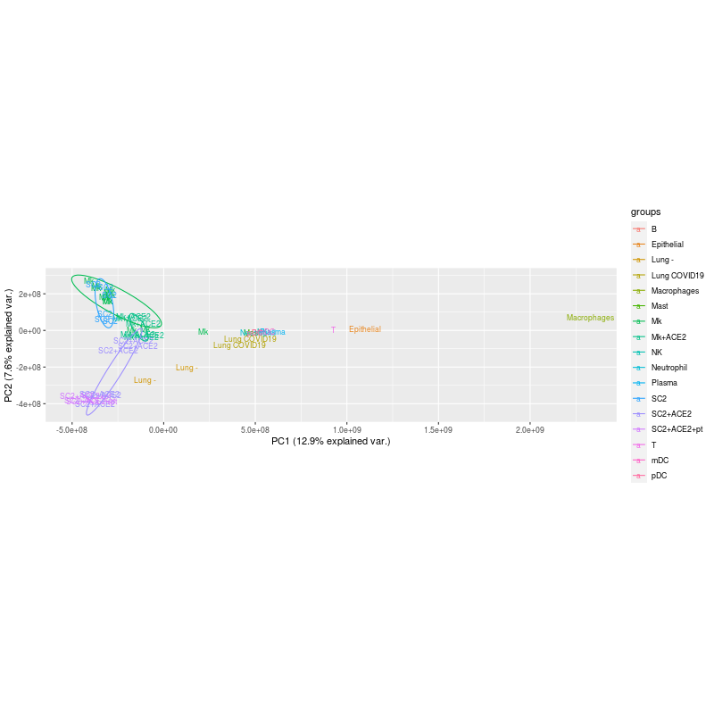

**v2**

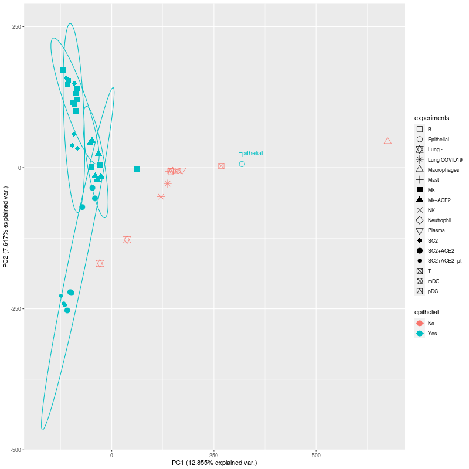

- PC2&3

**v1**

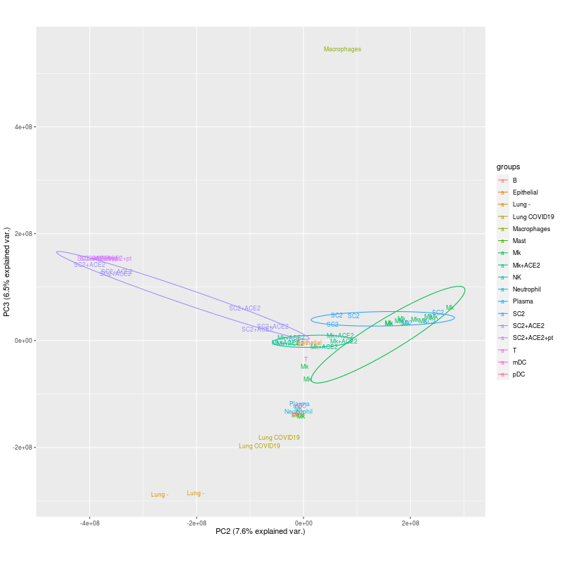

**v2**

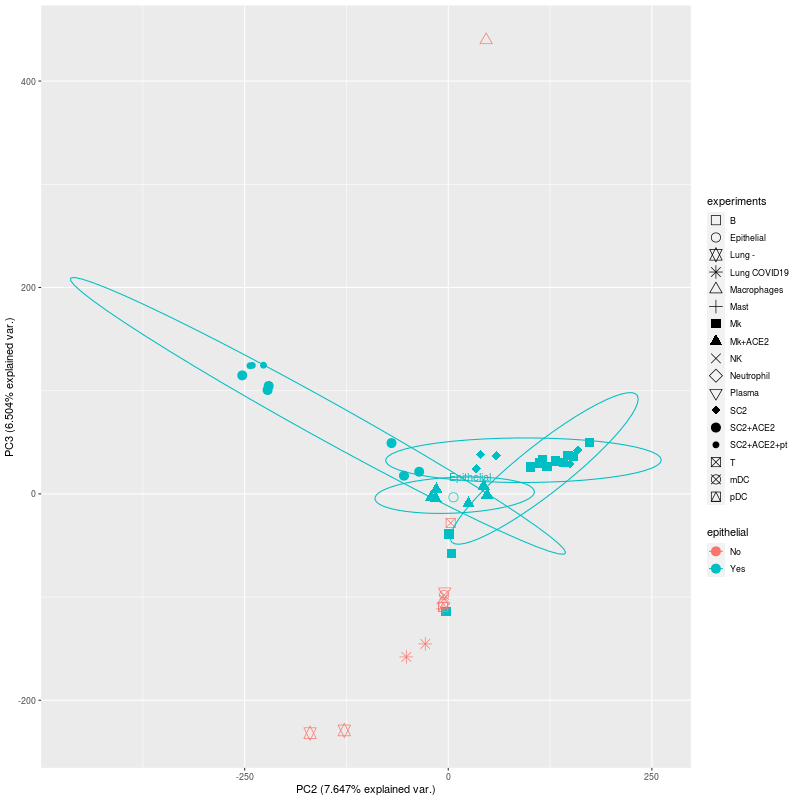

- PC3&4

**v1**

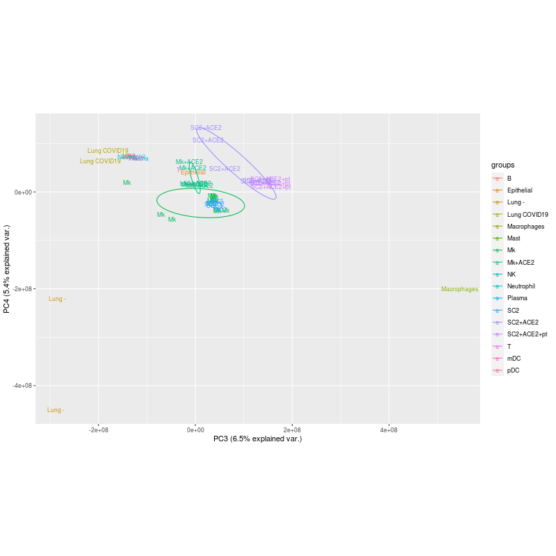

**v2**

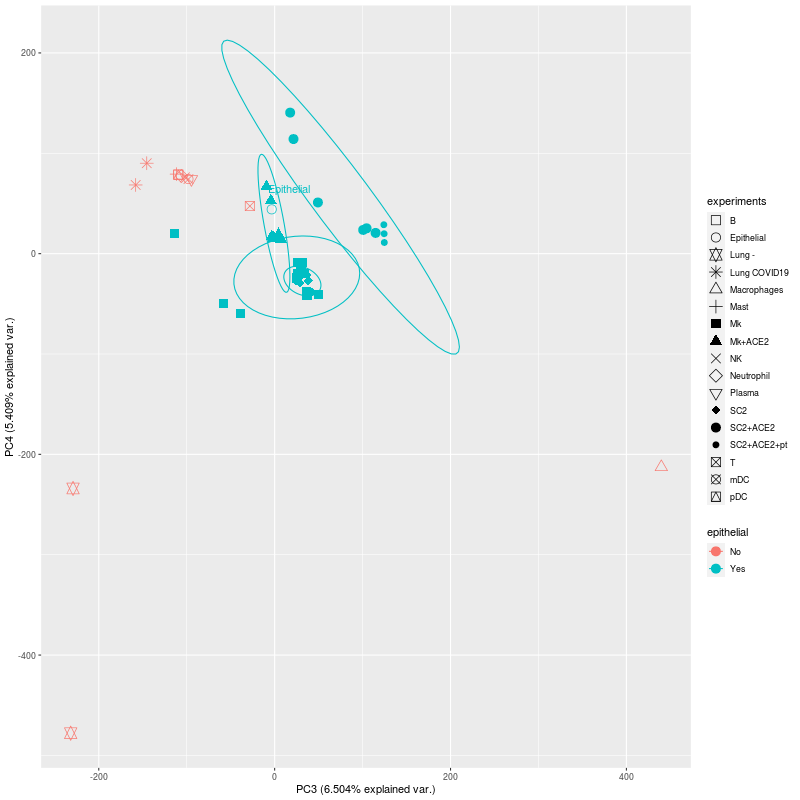

### **Conclusions**

**PCA of bulk samples: Mock treated and SARS-CoV-2 infected samples**

See below for notation*.

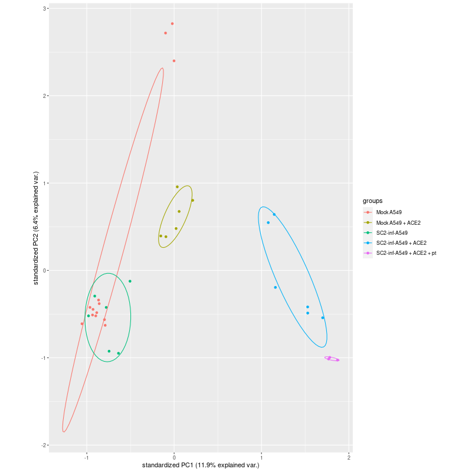

In the bulk samples PCA plot, samples seem grouped by experimental conditions, except a little for SC2 infected samples, but this could be due to lack of effect of the virus given the low or non expression of ACE2. Groups disperse in a experimental wise manner, ie. it makes sense mock samples being close to non ACE2 infected samples, and close by PC1 to mock samples expressing ACE2, then SC2 infected samples with ACE2 expression and then those with INF-I block.

*Bulk notation:

- `Mock A549` or `Mk` : Mock treated A459 cell lines samples
- `Mock A549 + ACE2` or `Mk+ACE2` : Mock treated A459 cell lines with vector expression of ACE2 samples
- `SC2-inf-A549` or `SC2`: SARS-CoV-2 infected A459 cell lines samples
- `SC2-inf-A549 + ACE2` or `SC2+ACE2` : SARS-CoV-2 infected A459 cell lines with vector expression of ACE2 samples
- `SC2-inf-A549 + ACE2 + pt` or `SC2+ACE2+pt` : SARS-CoV-2 infected A459 cell lines with vector expression of ACE2 with 1hr Ruxolitinib pre-treatment (IFN-I signaling blocked) samples

**PCA of pseudo-bulk + all bulk data. Bronchoalveolar immune cell types + treated A459 cell lines**

- PC1&2: `22.5% explained variation`

**v1**

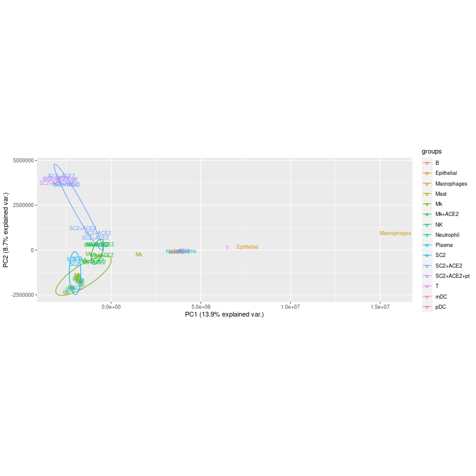

**v2**

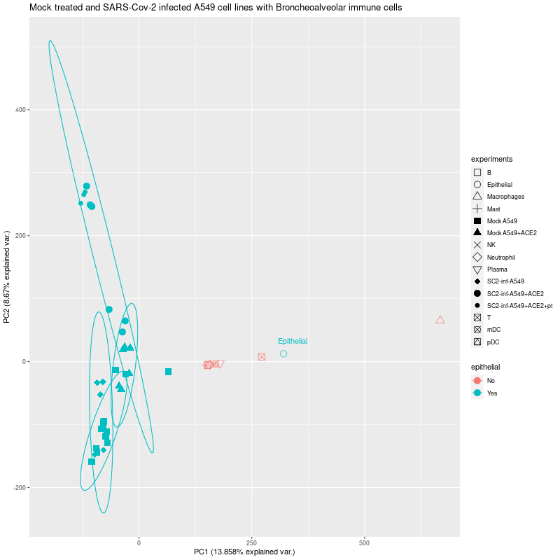

PC1 mainly separates data by data type. PC2 separates data mainly by bulk variability, with bulk experimental groups separating similarly to how they separate alone in a PCA (see PCA in bulk > Both > PCA > PC1&2). Pseudo-bulk data groups as before, with most immune cells forming a cluster, T and Epithelial farther away from bulk and Macrophages being an outlier.

**v1**

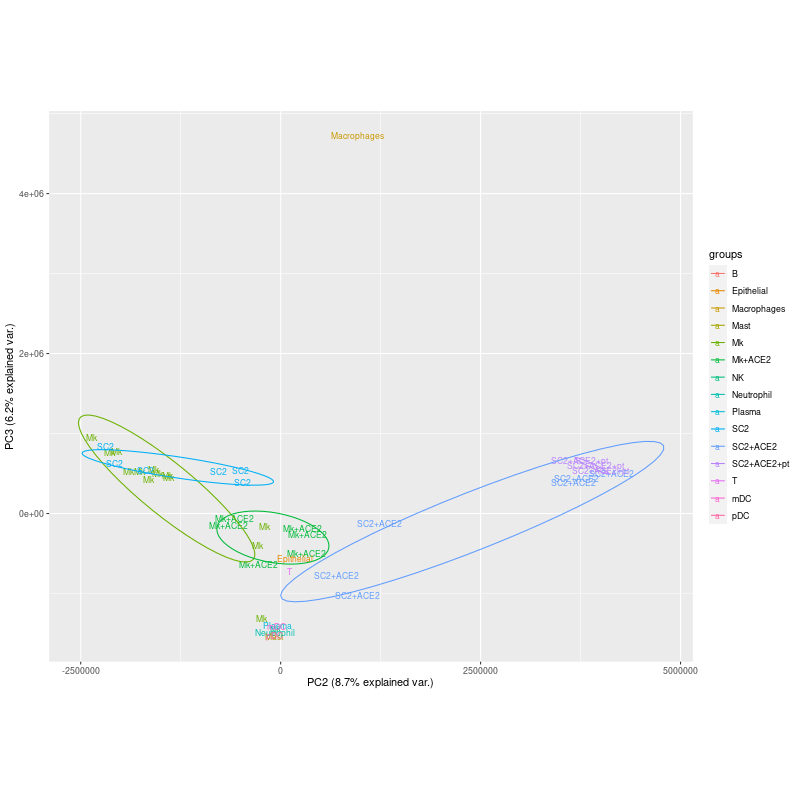

Data types are joined in this plot. Epithelial cell type locates within Mock samples with ACE2, but also close to Mock and SC2-infected samples with ACE2. T cell type is near but closer to SC2-infected ACE2. The cluster of immune cells locates out of bulk predicted distributions but near a Mock sample and below SC2-infected ACE2 samples.

**v2**

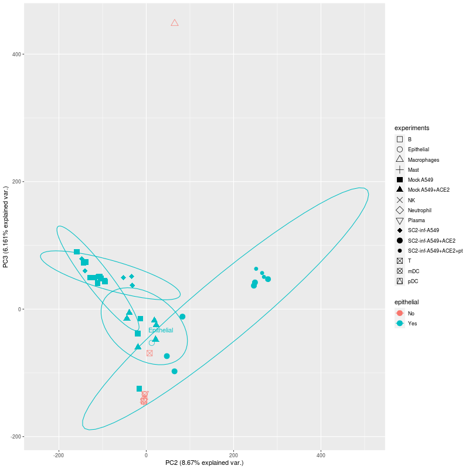

### **Refs**

In collaboration with Leonardo Arteaga, Ana Betty Villaseñor Altamirano, Karen Nuñez Reza and Alejandra Medina Rivera.

**References:**

[1] Liao, M., Liu, Y., Yuan, J., Wen, Y., Xu, G., Zhao, J., … & Zhang, Z. (2020). Single-cell landscape of bronchoalveolar immune cells in patients with COVID-19. Nature medicine, 26(6), 842-844.

[2] Blanco-Melo, D., Nilsson-Payant, B. E., Liu, W. C., Uhl, S., Hoagland, D., Møller, R., … & Albrecht, R. A. (2020). Imbalanced host response to SARS-CoV-2 drives development of COVID-19. Cell, 181(5), 1036-1045.

[3] Zhang, Y., Parmigiani, G., & Johnson, W. E. (2020). ComBat-seq: batch effect adjustment for RNA-seq count data. NAR genomics and bioinformatics, 2(3), lqaa078.

[4] Foster, K. A., Oster, C. G., Mayer, M. M., Avery, M. L., & Audus, K. L. (1998). Characterization of the A549 cell line as a type II pulmonary epithelial cell model for drug metabolism. Experimental cell research, 243(2), 359-366.

**Programs and versions:**

- R 4.0.2

  packages:
  - SingleCellExperiment
  - scuttle
  - Seurat
  - tidyverse
    - dplyr
    - stringr
    - ggplot2
  - biomaRt
  - ggbiplot
  - sva
    - ComBat-seq

*Last update: Oct 4th,2021*